# Machine Learning for Finance

Joan Antoni Seguí

# Problem Set 1

## 1. Show that the EWMA-based variance $\sigma^2_{ewma}$ can be obtained from the following recursion: $\sigma^2_{ewma}(t)=\lambda\sigma^2_{ewma}(t-1)+(1-\lambda)r^2_{t-1}$:

Plug in $\sigma^2_{ewma}(t-1)=\lambda\sigma^2_{ewma}(t-2)+(1-\lambda)r^2_{t-2}$ into the previous formula, we get:

$$\sigma^2_{ewma}(t)=\lambda(\lambda\sigma^2_{ewma}(t-2)+(1-\lambda)r^2_{t-2})+(1-\lambda)r^2_{t-1}$$

$$\sigma^2_{ewma}(t)=\lambda^2\sigma^2_{ewma}(t-2)+(1-\lambda)(\lambda r^2_{t-2}+r^2_{t-1})$$

Doing the same recursion, i.e. plug in $\sigma^2_{ewma}(t-2)=\lambda\sigma^2_{ewma}(t-3)+(1-\lambda)r^2_{t-3}$ into the previous formula, we get:

$$\sigma^2_{ewma}(t)=\lambda^2(\lambda\sigma^2_{ewma}(t-3)+(1-\lambda)r^2_{t-3})+(1-\lambda)(\lambda r^2_{t-2}+r^2_{t-1})$$

$$\sigma^2_{ewma}(t)=\lambda^3\sigma^2_{ewma}(t-3)+(1-\lambda)(\lambda^2r_{t-3}+\lambda r^2_{t-2}+r^2_{t-1})$$

As t increases (and $\lambda<1$), this recursive expression can be expressed as:

$$\sigma^2_t=(1-\lambda)\sum_{k=1}^{m}\lambda^{k-1}r^2_{t-k}$$

Using EMA with $\lambda=0.94$ for the returns of $IBEX35$ from 1999-01-04 to 2020-04-29 we get a volatility for 2020-04-29 of 0.029. If we use the regular standard deviation, we get a volatility of 0.015. It is reasonable to think that nowdays volatility is higher than the static volatility using all the sample because of COVID-19, which is increasing uncertainty in the financial markets.

## 2. Give a proof of the fact that the best estimator for $X_{t+h}$ with information set $Z=(X_{t},X_{t-1},...,X_{t-p})$ is a linear regression on $Z$, when all variables follow a normal distribution.

An estimation $\hat{X}_{t+h}$ of $X_{t+h}$ is viewed as a function of $Z$, $F(Z)=\hat{X}_{t+h}$. The best estimator of $F$ is the one that minimizes $E(X-F(Z))^2$.

$$E[(X_{t+h}-F(Z))^2]=E[(X_{t+h}-E(X_{t+h}|Z)+E(X_{t+h}|Z)-F(Z))^2]$$
$$=E[(X_{t+h}-E(X_{t+h}|Z))^2+2(X_{t+h}-E(X_{t+h}|Z))(E(X_{t+h}|Z)-F(Z))+(E(X_{t+h}|Z)-F(Z))^2]$$

$$=E[E((X_{t+h}-E(X_{t+h}|Z))^2|Z)]+E[2(E(X_{t+h}|Z)-F(Z))E((X_{t+h}-E(X_{t+h}|Z))|Z)]+E[(E(X_{t+h}|Z)-F(Z))^2]$$

$$=E[Var(X_{t+h}|Z)]+E[(E(X_{t+h}|Z)-F(Z))^2]$$

which is minimized when $F(Z)=E(X_{t+h}|Z)$

The conditional distribution of X given Z is $E(X|Z)=\mu_x+\rho\frac{\sigma_x}{\sigma_z}(Z-\mu_z)$, and we know that this is the best predictor.

Note that this is a linear regression $F(Z)=\alpha +\beta Z$ where $\beta=\rho\frac{\sigma_x}{\sigma_z}$ and $\alpha=\mu_x+\rho\frac{\sigma_X}{\sigma_z}\mu_z$

## 3.

Weekly causal returns 2018-01-01 / 2019-12-31

India

Brasil

France

Germany

USA

China

Spain

Indonesia

Mexico

Japan

Taiwan

VIX

VLIC

India

0000

0000

0000

0000

0000

0000

0000

0000

0000

1000

0000

0000

Brasil

0000

0000

0000

0000

0000

0000

0000

0001

0000

0000

0000

0000

France

0000

0000

0000

0000

0000

0000

0000

0000

1100

1000

0000

0000

Germany

0000

0000

0000

0000

0000

0000

0000

0000

1110

1011

0000

0000

USA

0000

0000

0000

0000

0111

0000

0000

0000

1111

0010

0010

1111

China

0000

0001

0000

0011

1100

0000

0000

0001

1111

0000

0001

1000

Spain

0000

0000

0000

0000

0000

0000

0000

0000

1111

1011

0000

0000

Indonesia

0000

0000

0000

0000

0000

0000

0000

0000

0000

0000

0000

0000

Mexico

0000

0000

0000

1101

1111

0000

1101

0010

1000

0000

0000

1101

Japan

0000

0000

0000

0000

0000

0000

0000

0000

0000

0011

0000

0100

Taiwan

0000

0000

0000

0000

0000

0000

0000

0000

0000

0000

0000

0000

VIX

0000

0000

0000

0000

0000

0001

0000

0000

0000

1111

1010

0000

VLIC

0000

0000

0000

0000

1111

0111

0000

0000

0000

1111

1010

0000

Weekly volatility spill-over 2018-01-01 / 2019-12-31

India

Brasil

France

Germany

USA

China

Spain

Indonesia

Mexico

Japan

Taiwan

VLIC

VIX

India

0000

0001

0111

1100

0100

0101

1000

0000

0000

0111

1100

0111

Brasil

0000

0000

1000

1000

0000

0000

0000

0000

0000

0000

1000

0000

France

1000

0000

0111

0000

1111

0111

0000

0100

0111

0000

0000

1111

Germany

0000

0000

1111

0000

0000

0000

0000

1001

0000

0000

0000

0000

USA

0000

0000

0000

0000

0000

0000

0000

0000

0011

1000

0000

0000

China

0000

0000

1111

1110

0000

0100

0000

1100

1000

0100

0000

0111

Spain

0000

0000

1111

0000

0000

1111

0000

0000

1000

0000

0000

0000

Indonesia

0000

0000

1001

0000

0000

0000

0000

0000

0000

0000

0000

0000

Mexico

1000

0000

0000

0000

0100

1111

0000

0000

0000

1010

0000

1111

Japan

0000

0000

1011

0000

1011

0000

0000

0000

0000

0000

0011

0000

Taiwan

0000

0000

1001

0011

1111

0010

0000

0000

1000

1010

1100

0000

VLIC

1100

0000

0000

0000

0001

0111

0011

0000

0000

0011

1111

1110

VIX

1000

0000

1000

1000

1100

1111

1111

0000

1000

1111

0000

1100

Monthly causal returns 2018-01-01 / 2019-12-31

India

Brasil

France

Germany

USA

China

Spain

Indonesia

Mexico

Japan

Taiwan

VIX

VLIC

India

0100

0000

0000

0000

0100

0000

0000

0000

0000

0000

0110

0000

Brasil

0000

0000

0000

0010

0000

0000

0000

0000

0000

0001

0000

0000

France

0000

0000

0000

0000

0000

0000

0000

0000

0000

0000

0000

0000

Germany

0000

0000

0000

0111

0010

0000

0000

0000

0000

0000

0011

0111

USA

0000

0000

0000

0100

0000

0000

0000

0000

0000

0000

1110

0000

China

0000

0000

0000

0000

0000

0000

0000

0000

0000

0000

0000

0000

Spain

0000

0010

0000

0000

0000

0000

0000

0000

0000

0000

0000

0000

Indonesia

0000

0101

0000

0000

0000

0000

0000

0000

0000

0000

0000

0000

Mexico

0000

0000

0000

0000

0001

0000

0000

0000

0100

0000

0000

0000

Japan

0000

0000

0000

0000

0000

0000

0000

0000

0000

0000

0000

0000

Taiwan

0000

0000

0000

0000

0011

0000

0000

0000

0000

0000

0000

0000

VIX

0011

0000

0000

0000

0000

0000

0000

0000

0000

0000

0000

0000

VLIC

0000

0000

0000

0000

0000

0000

0000

0000

0000

0000

0000

0000

Monthly volatility spill-over 2018-01-01 / 2019-12-31

India

Brasil

France

Germany

USA

China

Spain

Indonesia

Mexico

Japan

Taiwan

VLIC

VIX

India

0000

0000

0001

0001

0000

1000

0000

0000

0000

0000

0000

0000

Brasil

1111

0000

0000

0000

0000

0000

0011

0000

0000

0000

0000

0000

France

0000

0000

0000

0000

1000

0000

0000

0000

0000

0000

0000

0000

Germany

0000

0000

0000

0000

0000

0110

0011

0000

0000

0000

0010

0000

USA

0000

0000

0000

0000

0000

0000

0000

0000

0011

0000

0000

0000

China

0000

0000

0000

0000

0000

0000

0111

0000

0000

0000

0000

0000

Spain

0101

0000

0000

0000

0000

0000

0000

0000

0000

0000

0001

0000

Indonesia

1110

0000

0000

0000

0000

0000

0000

0000

0000

0000

0000

0000

Mexico

0000

0000

0000

0111

0001

0000

0000

0000

1111

0000

1111

0000

Japan

0000

0000

0000

1111

0111

0000

0000

0011

0000

0000

1111

0000

Taiwan

0000

0000

0000

0000

0111

0000

0000

0000

0000

0111

0001

0000

VLIC

0000

0000

0000

0000

0000

0000

0001

0000

0001

1011

0000

0000

VIX

0000

0000

0000

0000

0000

0000

0000

0000

0000

0000

0000

0000

## 4.

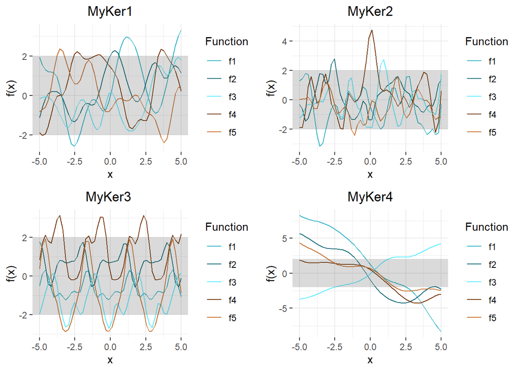

Kernel 3 is a periodic kernel, with a fairly low lenghtscale, so it has a higher variation within a repetition.

Kernel 4 is a combination of a linear kernel and an exponentiated quadratic. It is the unique kernel which is not stationary, we can see how the value of the kernel does not only depend on the distance between the two points, but on their absolute value.

## 5

$$kernel1 =2*exp((\sum((x-y)^2))/(-2*1.5^2))$$
$$kernel2 = 2*exp(\sum(abs(x-y))/(-2*1.5^2)) + 1.5*\sum(x*y)$$

The regression used is $GSPCep_t = GSPCep_{t-1} +GSPCep_{t-2}+GSPCep_{t-3} + dp_t + dp_{t-1} +dp_{t-2}+dy_t+dy_{t-1}+dy_{t-2}+ep_t+ep_{t-1}+ep_{t-2}$

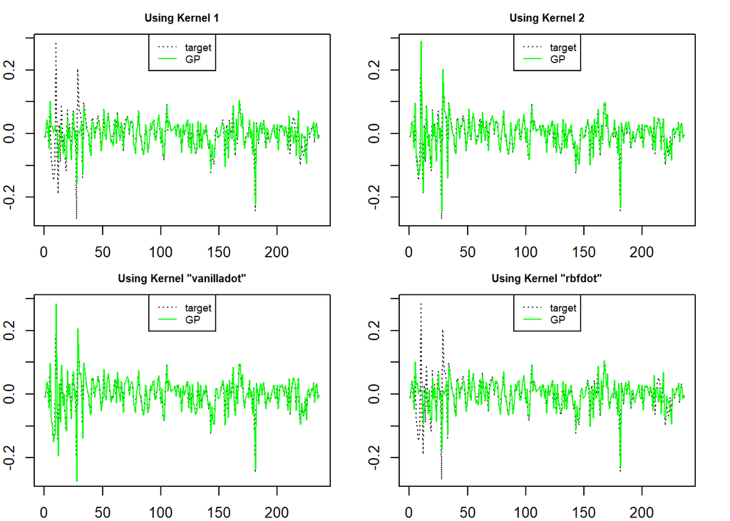

percentage of outperforming direct sample mean:

- kernel 1: 42.5%
- kernel 2: 90.2%
- kernel 3: 97.3%
- kernel 4: 48.9%

# Problem Set 2

## 1. Backtesting trading strategies based on sentiment indicators

### i) Testing performance of MAcross strategy

In all of the following rolling window analysis we will be using a window size of 3 months. The periods for the moving average will be: 5,10,15,20 for the short-term one, and 25,50 for the long-term one.

Here we test Long-only Bull-Bear Ratio,

Long-only Bull-Bear Ratio

|  | Cumulative Return | Annual Return | Annualized Sharpe Ratio | Win % | Annualized Volatility | Maximum Drawdown | Max Length Drawdown |
| --- | --- | --- | --- | --- | --- | --- | --- |
| Me_5/25 | -0.0354952 | -0.1308798 | -0.6617871 | 0.4830093 | 0.1913029 | -0.0762390 | 47.64516 |
| Me_5/50 | -0.1218313 | -0.4049657 | -1.6732958 | 0.4582632 | 0.2420297 | -0.1307137 | 61.50000 |
| Me_10/25 | 0.0047500 | 0.0245770 | 0.2201922 | 0.4615475 | 0.1598163 | -0.0619014 | 42.77419 |
| Me_10/50 | -0.1189291 | -0.3970606 | -1.6147890 | 0.4950938 | 0.2459026 | -0.1373898 | 55.50000 |
| Me_15/25 | -0.0171972 | -0.0652363 | -0.3721650 | 0.4651059 | 0.1690519 | -0.0660451 | 28.96774 |
| Me_15/50 | -0.0825788 | -0.2907875 | -1.4479525 | 0.5238095 | 0.2006020 | -0.1061134 | 55.50000 |
| Me_20/25 | 0.0403673 | 0.1775074 | 0.8224975 | 0.4831079 | 0.2326038 | -0.0675140 | 28.41935 |
| Me_20/50 | -0.1974763 | -0.5849877 | -2.3388193 | 0.4574245 | 0.2501336 | -0.2112310 | 55.50000 |
| B&H | -0.2249478 | -0.6356960 | -1.2764274 | 0.4818228 | 0.4975479 | -0.3158025 | 43.00000 |

Long-Short Bull-Bear Ratio

|  | Cumulative Return | Annual Return | Annualized Sharpe Ratio | Win % | Annualized Volatility | Maximum Drawdown | Max Length Drawdown |
| --- | --- | --- | --- | --- | --- | --- | --- |
| Me_5/25 | 0.1388953 | 0.6895390 | 1.3868778 | 0.5012801 | 0.4991600 | -0.1579056 | 33.00000 |
| Me_5/50 | -0.0033179 | -0.0122106 | -0.0238153 | 0.4656085 | 0.5150440 | -0.1439447 | 42.50000 |
| Me_10/25 | 0.2323455 | 1.3156602 | 2.6564789 | 0.4772145 | 0.4971225 | -0.1525828 | 32.87097 |
| Me_10/50 | 0.0037335 | 0.0160414 | 0.0310394 | 0.4973545 | 0.5150157 | -0.1439447 | 42.50000 |
| Me_15/25 | 0.1805303 | 0.9475685 | 1.8979883 | 0.4782386 | 0.4983577 | -0.1439447 | 37.00000 |
| Me_15/50 | 0.0826152 | 0.3753009 | 0.7300253 | 0.5291005 | 0.5143210 | -0.1830294 | 42.50000 |
| Me_20/25 | 0.3310082 | 2.1602295 | 4.3885191 | 0.4992320 | 0.4943297 | -0.1218697 | 24.83871 |
| Me_20/50 | -0.1664178 | -0.5166821 | -1.0059249 | 0.4523810 | 0.5136845 | -0.1877696 | 55.50000 |
| B&H | -0.2645691 | -0.7071342 | -1.3854613 | 0.4973545 | 0.5103879 | -0.3158025 | 55.50000 |

The best combination (in terms of Annualized Sharpe Ratio) is again using s=20 m=25. It gives better results than only using long-positions. Not only for this specific combinations. There are other combinations with a positive cumulative Return. The win rate for all combinations is near 50%

Long-only PNlog

|  | Cumulative Return | Annual Return | Annualized Sharpe Ratio | Win % | Annualized Volatility | Maximum Drawdown | Max Length Drawdown |
| --- | --- | --- | --- | --- | --- | --- | --- |
| Me_5/25 | 0.0840197 | 0.3842243 | 1.5405688 | 0.5399545 | 0.2508044 | -0.0498532 | 34.22581 |
| Me_5/50 | 0.1305298 | 0.6339075 | 2.6755181 | 0.6065958 | 0.2369851 | -0.0438966 | 26.00000 |
| Me_10/25 | 0.0459642 | 0.2058443 | 0.8917045 | 0.4668683 | 0.2395865 | -0.0662169 | 28.41935 |
| Me_10/50 | -0.0361182 | -0.1358356 | -0.8817291 | 0.4938272 | 0.1531419 | -0.0760278 | 24.50000 |
| Me_15/25 | 0.0056726 | 0.0263142 | 0.1059318 | 0.4567625 | 0.2717007 | -0.0867646 | 20.67742 |
| Me_15/50 | -0.0112114 | -0.0435578 | -0.3174700 | 0.5372596 | 0.1367415 | -0.0573265 | 55.50000 |
| Me_20/25 | -0.2283844 | -0.6439624 | -2.6078508 | 0.4115492 | 0.2468589 | -0.2592385 | 51.70968 |
| Me_20/50 | -0.1772579 | -0.5416952 | -2.2197009 | 0.4538144 | 0.2440387 | -0.2050229 | 55.50000 |
| B&H | -0.2645691 | -0.7071342 | -1.3854613 | 0.4973545 | 0.5103879 | -0.3158025 | 55.50000 |

Long-short PNlog

|  | Cumulative Return | Annual Return | Annualized Sharpe Ratio | Win % | Annualized Volatility | Maximum Drawdown | Max Length Drawdown |
| --- | --- | --- | --- | --- | --- | --- | --- |
| Me_5/25 | 0.4484693 | 3.4187800 | 6.9703484 | 0.5555556 | 0.4904114 | -0.0898269 | 21.22581 |
| Me_5/50 | 0.6511856 | 6.4524737 | 12.9837568 | 0.5846561 | 0.4969940 | -0.0705263 | 22.50000 |
| Me_10/25 | 0.3460327 | 2.3094544 | 4.6994005 | 0.4838710 | 0.4938392 | -0.0981286 | 18.83871 |
| Me_10/50 | 0.1900158 | 1.0077615 | 1.9671546 | 0.4973545 | 0.5124392 | -0.1720545 | 42.50000 |
| Me_15/25 | 0.2495089 | 1.4425752 | 2.9086754 | 0.4633897 | 0.4967129 | -0.0949104 | 26.09677 |
| Me_15/50 | 0.2512930 | 1.4626477 | 2.8622370 | 0.5291005 | 0.5109537 | -0.1439447 | 42.00000 |
| Me_20/50 | -0.1245160 | -0.4110076 | -0.7992041 | 0.4576720 | 0.5144381 | -0.1877439 | 55.50000 |
| B&H | -0.2645691 | -0.7071342 | -1.3854613 | 0.4973545 | 0.5103879 | -0.3158025 | 55.50000 |

Allowing PNlog to trade short positions improves the results. Now the best combination has a cumulative return of 0.65 and Sharpe-ratio of 12.98

Long-only positiveP

|  | Cumulative Return | Annual Return | Annualized Sharpe Ratio | Win % | Annualized Volatility | Maximum Drawdown | Max Length Drawdown |
| --- | --- | --- | --- | --- | --- | --- | --- |
| Me_5/25 | 0.1134030 | 0.5398778 | 2.1723718 | 0.6140371 | 0.2494797 | -0.0663093 | 17.87097 |
| Me_5/50 | 0.0241206 | 0.1002815 | 0.3146400 | 0.5873574 | 0.3188461 | -0.1100637 | 14.50000 |
| Me_10/25 | 0.0298512 | 0.1309326 | 0.5504707 | 0.4802634 | 0.2470743 | -0.0849157 | 30.16129 |
| Me_10/50 | -0.0671196 | -0.2422358 | -0.8834355 | 0.4708095 | 0.2742043 | -0.1492103 | 34.50000 |
| Me_15/25 | 0.0197912 | 0.0847951 | 0.3170824 | 0.4851427 | 0.2751391 | -0.0865914 | 21.64516 |
| Me_15/50 | -0.0777720 | -0.2762135 | -1.1310561 | 0.5128824 | 0.2442229 | -0.0967056 | 55.50000 |
| Me_20/25 | -0.1141877 | -0.3804569 | -1.1692757 | 0.4553404 | 0.3236793 | -0.1943470 | 57.51613 |
| Me_20/50 | -0.1546687 | -0.4892512 | -1.7320861 | 0.5021187 | 0.2824597 | -0.1687467 | 55.50000 |
| B&H | -0.2645691 | -0.7071342 | -1.3854613 | 0.4973545 | 0.5103879 | -0.3158025 | 55.50000 |

Long-short positiveP

|  | Cumulative Return | Annual Return | Annualized Sharpe Ratio | Win % | Annualized Volatility | Maximum Drawdown | Max Length Drawdown |
| --- | --- | --- | --- | --- | --- | --- | --- |
| Me_5/25 | 0.5282918 | 4.4876525 | 9.2022273 | 0.6272401 | 0.4873850 | -0.0887437 | 11.93548 |
| Me_5/50 | 0.3699315 | 2.5311187 | 4.9870565 | 0.6005291 | 0.5075145 | -0.0887437 | 13.00000 |
| Me_10/25 | 0.3066449 | 1.9438470 | 3.9400370 | 0.4956477 | 0.4950456 | -0.1367046 | 22.48387 |
| Me_10/50 | 0.1291435 | 0.6271750 | 1.2209569 | 0.4656085 | 0.5136299 | -0.2210777 | 34.50000 |
| Me_15/25 | 0.2861901 | 1.7598819 | 3.5452005 | 0.4971838 | 0.4956750 | -0.0947477 | 18.80645 |
| Me_15/50 | 0.0993754 | 0.4635714 | 0.9014488 | 0.5211640 | 0.5140852 | -0.1987566 | 42.50000 |
| Me_20/25 | -0.0229093 | -0.0811480 | -0.1588814 | 0.4623656 | 0.5007693 | -0.1830370 | 38.70968 |
| Me_20/50 | -0.0713179 | -0.2542639 | -0.4940339 | 0.5052910 | 0.5149677 | -0.1640785 | 55.50000 |
| B&H | -0.2645691 | -0.7071342 | -1.3854613 | 0.4973545 | 0.5103879 | -0.3158025 | 55.50000 |

Long-only negativeP

Long-only negativeP

|  | Cumulative Return | Annual Return | Annualized Sharpe Ratio | Win % | Annualized Volatility | Maximum Drawdown | Max Length Drawdown |
| --- | --- | --- | --- | --- | --- | --- | --- |
| Me_5/25 | -0.1968135 | -0.5797653 | -1.8044338 | 0.4695253 | 0.3204883 | -0.2228035 | 42.00000 |
| Me_5/50 | -0.1637546 | -0.5106971 | -1.2763763 | 0.4999139 | 0.4000717 | -0.2008305 | 54.50000 |
| Me_10/25 | -0.1651076 | -0.5119969 | -1.1398166 | 0.5273606 | 0.4487537 | -0.2811123 | 53.51613 |
| Me_10/50 | -0.2368921 | -0.6608875 | -1.3095188 | 0.5217391 | 0.5046797 | -0.3127020 | 54.50000 |
| Me_15/25 | -0.2982559 | -0.7567779 | -1.6913841 | 0.4570566 | 0.4475102 | -0.3489561 | 55.77419 |
| Me_15/50 | -0.2858930 | -0.7393365 | -1.4578657 | 0.4810099 | 0.5071151 | -0.3127020 | 54.50000 |
| Me_20/25 | -0.1163930 | -0.3873924 | -0.8146224 | 0.5279979 | 0.4747232 | -0.2894112 | 37.48387 |
| Me_20/50 | -0.2552180 | -0.6917891 | -1.3640721 | 0.5049101 | 0.5071214 | -0.2954133 | 53.50000 |
| B&H | -0.2645691 | -0.7071342 | -1.3854613 | 0.4973545 | 0.5103879 | -0.3158025 | 55.50000 |

Long-Short negativeP

|  | Cumulative Return | Annual Return | Annualized Sharpe Ratio | Win % | Annualized Volatility | Maximum Drawdown | Max Length Drawdown |
| --- | --- | --- | --- | --- | --- | --- | --- |
| Me_5/25 | -0.1967442 | -0.5776079 | -1.1566424 | 0.4884793 | 0.4984056 | -0.2426815 | 35.38710 |
| Me_5/50 | -0.0731662 | -0.2613135 | -0.5073488 | 0.5026455 | 0.5149741 | -0.1451133 | 35.50000 |
| Me_10/25 | -0.1108081 | -0.3719396 | -0.7427292 | 0.5473630 | 0.5003315 | -0.2947887 | 50.87097 |
| Me_10/50 | -0.2093904 | -0.6088818 | -1.1880476 | 0.5343915 | 0.5125525 | -0.3253851 | 62.83333 |
| Me_15/25 | -0.3711151 | -0.8431700 | -1.7269545 | 0.4695341 | 0.4886536 | -0.4366575 | 58.06452 |
| Me_15/50 | -0.3069114 | -0.7681618 | -1.5119400 | 0.4708995 | 0.5080617 | -0.3266473 | 62.83333 |
| Me_20/25 | 0.0014893 | 0.0095893 | 0.0209233 | 0.5519713 | 0.5007466 | -0.2894112 | 37.00000 |
| Me_20/50 | -0.2464139 | -0.6766438 | -1.3236607 | 0.5105820 | 0.5111732 | -0.2954133 | 53.50000 |
| B&H | -0.2645691 | -0.7071342 | -1.3854613 | 0.4973545 | 0.5103879 | -0.3158025 | 55.50000 |

Long-only BULL

|  | Cumulative Return | Annual Return | Annualized Sharpe Ratio | Win % | Annualized Volatility | Maximum Drawdown | Max Length Drawdown |
| --- | --- | --- | --- | --- | --- | --- | --- |
| Me_5/25 | 0.1244215 | 0.6042282 | 2.4697806 | 0.5977313 | 0.2490387 | -0.0489691 | 17.12903 |
| Me_5/50 | -0.0166110 | -0.0645926 | -0.1999652 | 0.5626898 | 0.3228753 | -0.1434008 | 37.33333 |
| Me_10/25 | 0.0337603 | 0.1478971 | 0.6209518 | 0.4943395 | 0.2465158 | -0.0849157 | 30.16129 |
| Me_10/50 | -0.2302420 | -0.6488309 | -1.4910177 | 0.5019242 | 0.4351593 | -0.2621981 | 48.50000 |
| Me_15/25 | -0.0256630 | -0.0869966 | -0.2705078 | 0.4749240 | 0.2908212 | -0.1034530 | 20.67742 |
| Me_15/50 | -0.0432029 | -0.1605288 | -0.5147193 | 0.5016327 | 0.3113932 | -0.1142295 | 23.50000 |
| Me_20/25 | -0.1104097 | -0.3698194 | -1.1361930 | 0.4690029 | 0.3236768 | -0.1910545 | 57.77419 |
| Me_20/50 | -0.1368130 | -0.4447109 | -1.2498132 | 0.5017623 | 0.3558163 | -0.1917250 | 55.50000 |
| B&H | -0.2645691 | -0.7071342 | -1.3854613 | 0.4973545 | 0.5103879 | -0.3158025 | 55.50000 |

Long-short BULL

|  | Cumulative Return | Annual Return | Annualized Sharpe Ratio | Win % | Annualized Volatility | Maximum Drawdown | Max Length Drawdown |
| --- | --- | --- | --- | --- | --- | --- | --- |
| Me_5/25 | 0.5580219 | 4.9117773 | 10.1215367 | 0.6057348 | 0.4861912 | -0.0887437 | 12.67742 |
| Me_5/50 | 0.2639061 | 1.5584450 | 3.0516260 | 0.5687831 | 0.5106376 | -0.1106485 | 12.00000 |
| Me_10/25 | 0.3164085 | 2.0286750 | 4.1137855 | 0.5110087 | 0.4947644 | -0.1367046 | 22.67742 |
| Me_10/50 | -0.2083386 | -0.6062008 | -1.1829015 | 0.5052910 | 0.5125633 | -0.2922770 | 48.50000 |
| Me_15/25 | 0.1761613 | 0.9564568 | 1.9429401 | 0.4854071 | 0.4982613 | -0.1369411 | 18.96774 |
| Me_15/50 | 0.1940481 | 1.0379252 | 2.0269117 | 0.5052910 | 0.5123462 | -0.1362698 | 23.50000 |
| Me_20/25 | -0.0145712 | -0.0493796 | -0.0952753 | 0.4782386 | 0.5007574 | -0.1768471 | 31.77419 |
| Me_20/50 | -0.0205498 | -0.0773301 | -0.1504460 | 0.5052910 | 0.5150716 | -0.1640785 | 23.50000 |
| B&H | -0.2645691 | -0.7071342 | -1.3854613 | 0.4973545 | 0.5103879 | -0.3158025 | 55.50000 |

Long-only BEAR

|  | Cumulative Return | Annual Return | Annualized Sharpe Ratio | Win % | Annualized Volatility | Maximum Drawdown | Max Length Drawdown |
| --- | --- | --- | --- | --- | --- | --- | --- |
| Me_5/25 | -0.1263303 | -0.4144732 | -1.1471010 | 0.5063423 | 0.3601010 | -0.2008305 | 42.00000 |
| Me_5/50 | -0.1088376 | -0.3682305 | -0.9392411 | 0.5296806 | 0.3918514 | -0.2008305 | 54.50000 |
| Me_10/25 | -0.2942389 | -0.7508775 | -1.6676308 | 0.4752493 | 0.4502446 | -0.3410781 | 42.03226 |
| Me_10/50 | -0.2765479 | -0.7257672 | -1.4578772 | 0.5037972 | 0.4978073 | -0.3127020 | 54.50000 |
| Me_15/25 | -0.2751669 | -0.7227838 | -1.6232629 | 0.4857317 | 0.4452758 | -0.3386316 | 57.87097 |
| Me_15/50 | -0.2592450 | -0.6983987 | -1.3779193 | 0.4937169 | 0.5068228 | -0.2954133 | 53.50000 |
| Me_20/25 | -0.1669896 | -0.5160379 | -1.0740849 | 0.4841207 | 0.4801591 | -0.2894112 | 37.67742 |
| Me_20/50 | -0.2100554 | -0.6099523 | -1.2147669 | 0.5249359 | 0.5020672 | -0.2894112 | 49.50000 |
| B&H | -0.2645691 | -0.7071342 | -1.3854613 | 0.4973545 | 0.5103879 | -0.3158025 | 55.50000 |

Long-short BEAR

|  | Cumulative Return | Annual Return | Annualized Sharpe Ratio | Win % | Annualized Volatility | Maximum Drawdown | Max Length Drawdown |
| --- | --- | --- | --- | --- | --- | --- | --- |
| Me_5/25 | -0.0438129 | -0.1611642 | -0.3196859 | 0.5258577 | 0.5008074 | -0.1380761 | 37.58065 |
| Me_5/50 | 0.0505609 | 0.2213345 | 0.4305746 | 0.5423280 | 0.5146665 | -0.1350857 | 29.50000 |
| Me_10/25 | -0.3635321 | -0.8350675 | -1.7073535 | 0.4956477 | 0.4893123 | -0.3992867 | 50.87097 |
| Me_10/50 | -0.2903892 | -0.7459602 | -1.4653451 | 0.5079365 | 0.5090611 | -0.3253851 | 62.83333 |
| Me_15/25 | -0.3297021 | -0.7974489 | -1.6217694 | 0.5033282 | 0.4920147 | -0.4276355 | 50.90323 |
| Me_15/50 | -0.2545623 | -0.6903972 | -1.3514958 | 0.4920635 | 0.5108233 | -0.2954133 | 53.50000 |
| Me_20/25 | -0.1085532 | -0.3656946 | -0.7313285 | 0.4992320 | 0.5003597 | -0.2894112 | 37.19355 |
| Me_20/50 | -0.1536760 | -0.4856056 | -0.9446965 | 0.5423280 | 0.5139662 | -0.2894112 | 49.50000 |
| B&H | -0.2645691 | -0.7071342 | -1.3854613 | 0.4973545 | 0.5103879 | -0.3158025 | 55.50000 |

As stated before, given the market and the situation it was easy to outperform the B&H strategy. However, we can see that strategies perform very different. The worst strategies are those using a BEARISH indicator and only trading LONG positions.

The best ones are Long-short positiveP, Long-Short PNlog, and Long-Short BBr.

### ii) Design your own strategy

Given the results that we got in the previous question I will adapt the RSI indicator on: Long-short positiveP, Long-Short PNlog, and Long-Short BBr. I will try using different number of periods. I will select the best indicator with the optimal number of periods and I will allow taking leveraged positions.

RSI(Bull Bear Ratio) for n=2:8

```
## [1] 2
##    Cumulative Return Annual Return Annualized Sharpe Ratio     Win %
## BH     -0.2078567207  -0.587206304             -1.28145138 0.4690027
## Me     -0.0005813667   0.005517638             -0.01123376 0.5375484
##    Annualized Volatility Maximum Drawdown Max Length Drawdown
## BH             0.4421158       -0.2909967            34.56604
## Me             0.3615486       -0.1354493            37.71698
## [1] 3
##    Cumulative Return Annual Return Annualized Sharpe Ratio     Win %
## BH        -0.2120365   -0.59923926             -1.31173025 0.4688645
## Me        -0.0137019   -0.04565264             -0.09799069 0.5531101
##    Annualized Volatility Maximum Drawdown Max Length Drawdown
## BH             0.4480911       -0.2954904            34.80769
## Me             0.3493574       -0.1387468            34.36538
## [1] 4
##    Cumulative Return Annual Return Annualized Sharpe Ratio     Win %
## BH       -0.21664251    -0.6128453              -1.3513933 0.4684096
## Me        0.02733134     0.1206110               0.4581711 0.6350095
##    Annualized Volatility Maximum Drawdown Max Length Drawdown
## BH             0.4542667       -0.3001603            35.05882
## Me             0.3360614       -0.1335708            30.43137
## [1] 5
##    Cumulative Return Annual Return Annualized Sharpe Ratio     Win %
## BH        -0.2208615    -0.6246508               -1.375259 0.4682540
## Me        -0.1234041    -0.4045236               -1.402580 0.4810598
##    Annualized Volatility Maximum Drawdown Max Length Drawdown
## BH             0.4604971       -0.3049301               35.32
## Me             0.2805177       -0.1411217               55.80
## [1] 6
##    Cumulative Return Annual Return Annualized Sharpe Ratio     Win %
## BH      -0.223736189  -0.631610672              -1.3762333 0.4680920
## Me       0.001041518   0.004192604               0.2449304 0.4218659
##    Annualized Volatility Maximum Drawdown Max Length Drawdown
## BH            0.46553483     -0.308369767            35.59184
## Me            0.01602807     -0.006370936            41.14286
## [1] 7
##    Cumulative Return Annual Return Annualized Sharpe Ratio    Win %
## BH      -0.226059498   -0.63687741               -1.369382 0.468254
## Me       0.004474383    0.01803452                1.229143 0.584375
##    Annualized Volatility Maximum Drawdown Max Length Drawdown
## BH            0.47060509     -0.311375835              35.875
## Me            0.01443201     -0.003078406              41.500
## [1] 8
##    Cumulative Return Annual Return Annualized Sharpe Ratio     Win %
## BH      -0.228367338  -0.642051170              -1.3607835 0.4687606
## Me       0.002488459   0.009993721               0.7484934 0.5035461
##    Annualized Volatility Maximum Drawdown Max Length Drawdown
## BH            0.47589467     -0.314449991            36.17021
## Me            0.01343693     -0.003078406            44.55319
```

RSI(positiveP) for n=2:8

```
## [1] 2
##    Cumulative Return Annual Return Annualized Sharpe Ratio     Win %
## BH        -0.2078567    -0.5872063               -1.281451 0.4690027
## Me         0.2547166     1.5171295                6.165954 0.6787429
##    Annualized Volatility Maximum Drawdown Max Length Drawdown
## BH             0.4421158      -0.29099673            34.56604
## Me             0.2441350      -0.04102978            27.81132
## [1] 3
##    Cumulative Return Annual Return Annualized Sharpe Ratio     Win %
## BH       -0.21203648    -0.5992393               -1.311730 0.4688645
## Me        0.07265784     0.3283881                2.810912 0.6974180
##    Annualized Volatility Maximum Drawdown Max Length Drawdown
## BH             0.4480911      -0.29549039            34.80769
## Me             0.1194193      -0.02340366            25.71154
## [1] 4
##    Cumulative Return Annual Return Annualized Sharpe Ratio     Win %
## BH       -0.21664251    -0.6128453               -1.351393 0.4684096
## Me        0.04737466     0.2041754                2.492290 0.6195612
##    Annualized Volatility Maximum Drawdown Max Length Drawdown
## BH            0.45426668       -0.3001603            35.05882
## Me            0.08135895       -0.0115593            31.37255
## [1] 5
##    Cumulative Return Annual Return Annualized Sharpe Ratio    Win %
## BH       -0.22086154   -0.62465084               -1.375259 0.468254
## Me        0.02246764    0.09365013                1.372932 0.645000
##    Annualized Volatility Maximum Drawdown Max Length Drawdown
## BH            0.46049708      -0.30493006               35.32
## Me            0.06481426      -0.01132895               35.78
## [1] 6
##    Cumulative Return Annual Return Annualized Sharpe Ratio     Win %
## BH       -0.22373619   -0.63161067               -1.376233 0.4680920
## Me        0.02276403    0.09490506                1.383390 0.6428571
##    Annualized Volatility Maximum Drawdown Max Length Drawdown
## BH            0.46553483      -0.30836977            35.59184
## Me            0.06537432      -0.01130326            35.59184
## [1] 7
##    Cumulative Return Annual Return Annualized Sharpe Ratio     Win %
## BH       -0.22605950   -0.63687741               -1.369382 0.4682540
## Me        0.02102822    0.08751086                1.230617 0.6041667
##    Annualized Volatility Maximum Drawdown Max Length Drawdown
## BH            0.47060509       -0.3113758            35.87500
## Me            0.06553272       -0.0112765            35.41667
## [1] 8
##    Cumulative Return Annual Return Annualized Sharpe Ratio     Win %
## BH       -0.22836734   -0.64205117              -1.3607835 0.4687606
## Me        0.01677419    0.06975015               0.8284302 0.5106383
##    Annualized Volatility Maximum Drawdown Max Length Drawdown
## BH             0.4758947       -0.3144500            36.17021
## Me             0.0638223       -0.0112486            35.25532
```

```
## [1] 1
##    Cumulative Return Annual Return Annualized Sharpe Ratio     Win %
## BH        -0.2544171     -0.688280               -1.410757 0.4618056
## Me         0.3408166      2.248339                4.621035 0.5530754
##    Annualized Volatility Maximum Drawdown Max Length Drawdown
## BH             0.4877949       -0.3409789            45.50000
## Me             0.4855696       -0.1199070            24.90625
## [1] 2
##    Cumulative Return Annual Return Annualized Sharpe Ratio     Win %
## BH        -0.2078567    -0.5872063               -1.281451 0.4690027
## Me         0.1035105     0.4976927                1.628126 0.5300090
##    Annualized Volatility Maximum Drawdown Max Length Drawdown
## BH             0.4421158       -0.2909967            34.56604
## Me             0.2843602       -0.0765283            20.07547
## [1] 3
##    Cumulative Return Annual Return Annualized Sharpe Ratio     Win %
## BH       -0.21203648    -0.5992393              -1.3117302 0.4688645
## Me        0.03827834     0.1677659               0.6311833 0.5941209
##    Annualized Volatility Maximum Drawdown Max Length Drawdown
## BH             0.4480911       -0.2954904            34.80769
## Me             0.2654136       -0.0731467            19.63462
## [1] 4
##    Cumulative Return Annual Return Annualized Sharpe Ratio     Win %
## BH       -0.21664251    -0.6128453              -1.3513933 0.4684096
## Me        0.03406003     0.1478160               0.5780006 0.5527544
##    Annualized Volatility Maximum Drawdown Max Length Drawdown
## BH             0.4542667      -0.30016027            35.05882
## Me             0.2638164      -0.07385906            26.96078
## [1] 5
##    Cumulative Return Annual Return Annualized Sharpe Ratio     Win %
## BH       -0.22086154    -0.6246508               -1.375259 0.4682540
## Me        0.05233846     0.2313090                1.409761 0.6004762
##    Annualized Volatility Maximum Drawdown Max Length Drawdown
## BH             0.4604971      -0.30493006               35.32
## Me             0.1430366      -0.03558834               33.10
## [1] 6
##    Cumulative Return Annual Return Annualized Sharpe Ratio     Win %
## BH       -0.22373619    -0.6316107               -1.376233 0.4680920
## Me        0.05012268     0.2213847                1.303104 0.5931973
##    Annualized Volatility Maximum Drawdown Max Length Drawdown
## BH             0.4655348      -0.30836977            35.59184
## Me             0.1433944      -0.03556328            33.16327
## [1] 7
##    Cumulative Return Annual Return Annualized Sharpe Ratio     Win %
## BH       -0.22605950    -0.6368774               -1.369382 0.4682540
## Me        0.05180014     0.2284167                1.373583 0.5930556
##    Annualized Volatility Maximum Drawdown Max Length Drawdown
## BH             0.4706051      -0.31137584             35.8750
## Me             0.1452183      -0.03553718             32.9375
## [1] 8
##    Cumulative Return Annual Return Annualized Sharpe Ratio     Win %
## BH       -0.22836734    -0.6420512               -1.360783 0.4687606
## Me        0.07793242     0.3543944                2.372355 0.7269504
##    Annualized Volatility Maximum Drawdown Max Length Drawdown
## BH             0.4758947       -0.3144500            36.17021
## Me             0.1367622       -0.0112486            34.95745
```

```
## [1] 0
##    Cumulative Return Annual Return Annualized Sharpe Ratio     Win %
## BH        -0.2078567    -0.5872063               -1.281451 0.4690027
## Me         0.2547166     1.5171295                6.165954 0.6787429
##    Annualized Volatility Maximum Drawdown Max Length Drawdown
## BH             0.4421158      -0.29099673            34.56604
## Me             0.2441350      -0.04102978            27.81132
## [1] 10
##    Cumulative Return Annual Return Annualized Sharpe Ratio     Win %
## BH        -0.2078567    -0.5872063               -1.281451 0.4690027
## Me         0.3741327     2.6714816                7.777418 0.6787429
##    Annualized Volatility Maximum Drawdown Max Length Drawdown
## BH             0.4421158      -0.29099673            34.56604
## Me             0.3359126      -0.05389763            27.81132
## [1] 20
##    Cumulative Return Annual Return Annualized Sharpe Ratio     Win %
## BH        -0.2078567    -0.5872063               -1.281451 0.4690027
## Me         0.5017293     4.3281430                9.689236 0.6787429
##    Annualized Volatility Maximum Drawdown Max Length Drawdown
## BH             0.4421158      -0.29099673            34.56604
## Me             0.4329375      -0.06675626            27.56604
## [1] 40
##    Cumulative Return Annual Return Annualized Sharpe Ratio     Win %
## BH        -0.2078567    -0.5872063               -1.281451 0.4690027
## Me         0.7825988    10.0312416               15.167608 0.6787429
##    Annualized Volatility Maximum Drawdown Max Length Drawdown
## BH             0.4421158      -0.29099673            34.56604
## Me             0.6330539      -0.09309516            27.56604
```

The win-ratio is 67% and the maximum length drawdown is 27. While for the B&H strategy the win-rate is 47% and the maximum length drawdown is 34. Without leverage we get a cumulative return of 0.25, a Sharpe ratio of 6.16 and a maximum drawdown of -0.04. As we increase leverage we get a higher cumulative return, a higher sharpe ratio, a higher volatility and a higher maximum drawdown.

## 2. Choose 7 stocks and compute long-only and long-short MinVar portfolio. Plot the Efficient Frontier for long-only portfolio in mean-variance space

Long-only MinVar portfolio

|  | x |
| --- | --- |
| AAPL | 0.00 |
| AMZN | 0.12 |
| HSBC | 0.87 |
| DB | 0.00 |
| DIS | 0.00 |
| FB | 0.01 |
| GOOG | 0.00 |

Long-short MinVar portfolio

|  | x |
| --- | --- |
| AAPL | -0.3550080 |
| AMZN | 0.3398505 |
| HSBC | 0.8940906 |
| DB | -0.1000796 |
| DIS | 0.3771613 |
| FB | -0.0516649 |
| GOOG | -0.1043499 |

Efficient Frontier for long-only portfolios

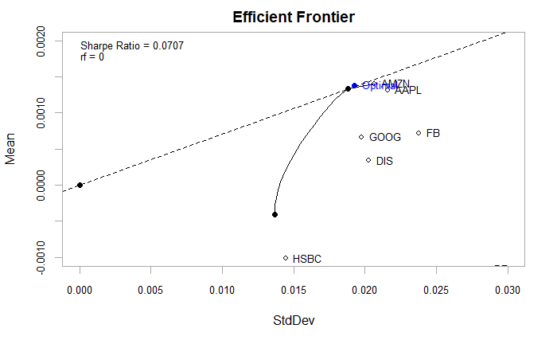

## 3. Give a proof for the fomrula for the variance of portfolio returns

$$Var(a_1X_1+a_2X_2)=E[(a_1X_1+a_2X_2-a_1\mu_{x_1}-a_2\mu_{x_2})^2]=E[(a_1(X_1-\mu_{x_1})+a_2(X_2-\mu_{x_2}))^2]=$$
$$E[a_1a_1(X_1-\mu_{x_1})^2+a_2a_2(X_2-\mu_{x_2})^2+a_1a_2(X_1-\mu_{x_1})(X_2-\mu_{x_2})]=$$
$$a_1a_1\sigma_{x_1}^2+a_2a_2\sigma_{x_2}^2+2a_1a_2\sigma_{x_1x_2}=$$
$$a_1a_1\sigma_{x_1}^2+a_2a_2\sigma_{x_2}^2+2a_1a_2\rho_{x_1x_2}\sigma_{x_1x_2}=$$

$$\sum_{i=1}^{2}\sum_{j=1}^{2}a_ia_j\sigma_i\sigma_j\rho_{ij}$$

Assume that for n=k holds:

$$Var \Bigg(\sum_{i=1}^{k}a_iX_i\Bigg)=\sum_{i=1}^{k}\sum_{j=1}^{k}a_ia_j\sigma_i\sigma_j\rho_{ij}$$

Show that n=k+1 holds:

$$Var \Bigg(\sum_{i=1}^{k+1}a_iX_i\Bigg)=\sum_{i=1}^{k+1}\sum_{j=1}^{k+1}a_ia_j\sigma_i\sigma_j\rho_{ij}$$

Developing LHS

$$Var \Bigg(\sum_{i=1}^ka_iX_i+a_{k+1}X_{k+1}\Bigg)=$$
$$Var (\sum_{i=1}^ka_iX_i)+Var(a_{k+1}X_{k+1})+2\sum_i^ka_ia_{k+1}\rho_{\sum_i^kX_iX_{k+1}}=$$
$$\sum_{i=1}^k\sum_{j=1}^ka_ia_j\sigma_i\sigma_j\rho_{ij}+a_{k+1}^2\sigma^2_{X_{k+1}}+2\sum_i^ka_ia_k\rho_{\sum_i^kX_iX_{k+1}} =$$

$$\sum_{i=1}^{k+1}\sum_{j=1}^{k+1}a_ia_j\sigma_i\sigma_j\rho_{ij}$$

## 4. Mean Variance approximation to Expected Utility

$$u^\prime(C)>0$$

$$u^{\prime\prime}(C)<0$$

Taking the second order taylor approximation to approximate the expected utility around $E(C)$

$$u(C) \approx u(E[C])+u^\prime(E[C])(C-E(C))+\frac{1}{2}u^{\prime\prime}(E[C])(C-E(C))^2$$

Taking Expectations

$$E[u(C)] \approx E[u(E[C])]+E[u^\prime(E[C])(C-E(C))]+E[\frac{1}{2}u^{\prime\prime}(E[C])(C-E(C))^2]$$

$E[u^\prime(E[C])(C-E(C))]=0$ and $E[\frac{1}{2}u^{\prime\prime}(E[C])(C-E(C))^2]=\frac{1}{2}u''(C)Var(C)$ and let $\lambda=-u{\prime\prime}(C)>0$
$$E[u(C)] \approx E[u(E[C])]- \frac{1}{2}\lambda Var(C)$$

# Project

```r
setwd("C:/Users/Jt_an/Google Drive/GSE - Finance/3 trim_/Machine Learning/Project")
AAPL <- read.csv('AAPL.csv', sep = ",", header = TRUE) #APPLE
ABBV <- read.csv('ABBV.csv', sep = ",", header = TRUE)
AMZN <- read.csv('AMZN.csv', sep = ",", header = TRUE) #AMAZON
DB <- read.csv('DB.csv', sep = ",", header = TRUE) # Deutsche Bank AG
DIS <- read.csv('DIS.csv', sep = ",", header = TRUE) # DISNEY
FB <- read.csv('FB.csv', sep = ",", header = TRUE) # FACEBOOK
GOOG <- read.csv('GOOG.csv', sep = ",", header = TRUE)  #GOOGLE
GRFS <- read.csv('GRFS.csv', sep = ",", header = TRUE)
HAL <- read.csv('HAL.csv', sep = ",", header = TRUE)
HSBC <- read.csv('HSBC.csv', sep = ",", header = TRUE) #BRITISH INVESTMENT BANK
JPM <- read.csv('JPM.csv', sep = ",", header = TRUE) #JPMORGAN CHASE
KO <- read.csv('KO.csv', sep = ",", header = TRUE)
MCD<- read.csv('MCD.csv', sep = ",", header = TRUE)
MSFT <- read.csv('MSFT.csv', sep = ",", header = TRUE) #Microsoft
PFE <- read.csv('PFE.csv', sep = ",", header = TRUE) # Pharmaceutical company
XOM <- read.csv('XOM.csv', sep = ",", header = TRUE)



symbols=c('AAPL','ABBV','AMZN','DB','DIS','FB','GOOG','GRFS','HAL','HSBC','JPM','KO','MCD','MSFT','PFE','XOM')


AAPL <- as.xts(zoo(as.matrix(AAPL[,-c(1,2)]), as.Date(as.character(AAPL[,2]))))
ABBV <- as.xts(zoo(as.matrix(ABBV[,-c(1,2)]), as.Date(as.character(ABBV[,2]))))
AMZN <- as.xts(zoo(as.matrix(AMZN[,-c(1,2)]), as.Date(as.character(AMZN[,2]))))
DB <- as.xts(zoo(as.matrix(DB[,-c(1,2)]), as.Date(as.character(DB[,2]))))
DIS <- as.xts(zoo(as.matrix(DIS[,-c(1,2)]), as.Date(as.character(DIS[,2]))))
FB <- as.xts(zoo(as.matrix(FB[,-c(1,2)]), as.Date(as.character(FB[,2]))))
GOOG <- as.xts(zoo(as.matrix(GOOG[,-c(1,2)]), as.Date(as.character(GOOG[,2]))))
GRFS <- as.xts(zoo(as.matrix(GRFS[,-c(1,2)]), as.Date(as.character(GRFS[,2]))))
HAL <- as.xts(zoo(as.matrix(HAL[,-c(1,2)]), as.Date(as.character(HAL[,2]))))
HSBC <- as.xts(zoo(as.matrix(HSBC[,-c(1,2)]), as.Date(as.character(HSBC[,2]))))
JPM <- as.xts(zoo(as.matrix(JPM[,-c(1,2)]), as.Date(as.character(JPM[,2]))))
KO <- as.xts(zoo(as.matrix(KO[,-c(1,2)]), as.Date(as.character(KO[,2]))))
MCD <- as.xts(zoo(as.matrix(MCD[,-c(1,2)]), as.Date(as.character(MCD[,2]))))
MSFT <- as.xts(zoo(as.matrix(MSFT[,-c(1,2)]), as.Date(as.character(MSFT[,2]))))
PFE <- as.xts(zoo(as.matrix(PFE[,-c(1,2)]), as.Date(as.character(PFE[,2]))))
XOM <- as.xts(zoo(as.matrix(XOM[,-c(1,2)]), as.Date(as.character(XOM[,2]))))

AAPLadj <- AAPL$Adj.Close
ABBVadj <- ABBV$Adj.Close
AMZNadj <- AMZN$Adj.Close
DBadj <- DB$Adj.Close
DISadj <- DIS$Adj.Close
FBadj <- FB$Adj.Close
GOOGadj <- GOOG$Adj.Close
GRFSadj <- GRFS$Adj.Close
HALadj <- HAL$Adj.Close
HSBCadj <- HSBC$Adj.Close
JPMadj <- JPM$Adj.Close
KOadj <- KO$Adj.Close
MCDadj <- MCD$Adj.Close
MSFTadj <- MSFT$Adj.Close
PFEadj <- PFE$Adj.Close
XOMadj <- XOM$Adj.Close


AAPLBBr <-  na.fill(100*.33*(na.omit(AAPL$positivePartscr)+na.omit(AAPL$certaintyPartscr)+na.omit(AAPL$finupPartscr))/(.33*(na.omit(AAPL$positivePartscr)+na.omit(AAPL$certaintyPartscr)+na.omit(AAPL$finupPartscr))+.33*(na.omit(AAPL$negativePartscr)+na.omit(AAPL$uncertaintyPartscr)+na.omit(AAPL$findownPartscr))),"extend")
AAPLPNlog <-0.5*log((na.omit(AAPL$positivePartscr)+1)/(na.omit(AAPL$negativePartscr)+1))

ABBVBBr <-  na.fill(100*.33*(na.omit(ABBV$positivePartscr)+na.omit(ABBV$certaintyPartscr)+na.omit(ABBV$finupPartscr))/(.33*(na.omit(ABBV$positivePartscr)+na.omit(ABBV$certaintyPartscr)+na.omit(ABBV$finupPartscr))+.33*(na.omit(ABBV$negativePartscr)+na.omit(ABBV$uncertaintyPartscr)+na.omit(ABBV$findownPartscr))),"extend")
ABBVPNlog <-0.5*log((na.omit(ABBV$positivePartscr)+1)/(na.omit(ABBV$negativePartscr)+1))

AMZNBBr <-  na.fill(100*.33*(na.omit(AMZN$positivePartscr)+na.omit(AMZN$certaintyPartscr)+na.omit(AMZN$finupPartscr))/(.33*(na.omit(AMZN$positivePartscr)+na.omit(AMZN$certaintyPartscr)+na.omit(AMZN$finupPartscr))+.33*(na.omit(AMZN$negativePartscr)+na.omit(AMZN$uncertaintyPartscr)+na.omit(AMZN$findownPartscr))),"extend")
AMZNPNlog <-0.5*log((na.omit(AMZN$positivePartscr)+1)/(na.omit(AMZN$negativePartscr)+1))

DBBBr <-  na.fill(100*.33*(na.omit(DB$positivePartscr)+na.omit(DB$certaintyPartscr)+na.omit(DB$finupPartscr))/(.33*(na.omit(DB$positivePartscr)+na.omit(AAPL$certaintyPartscr)+na.omit(DB$finupPartscr))+.33*(na.omit(DB$negativePartscr)+na.omit(DB$uncertaintyPartscr)+na.omit(DB$findownPartscr))),"extend")
DBPNlog <-0.5*log((na.omit(DB$positivePartscr)+1)/(na.omit(DB$negativePartscr)+1))

DISBBr <-  na.fill(100*.33*(na.omit(DIS$positivePartscr)+na.omit(DIS$certaintyPartscr)+na.omit(DIS$finupPartscr))/(.33*(na.omit(DIS$positivePartscr)+na.omit(DIS$certaintyPartscr)+na.omit(DIS$finupPartscr))+.33*(na.omit(DIS$negativePartscr)+na.omit(DIS$uncertaintyPartscr)+na.omit(DIS$findownPartscr))),"extend")
DISPNlog <-0.5*log((na.omit(DIS$positivePartscr)+1)/(na.omit(DIS$negativePartscr)+1))

FBBBr <-  na.fill(100*.33*(na.omit(FB$positivePartscr)+na.omit(FB$certaintyPartscr)+na.omit(FB$finupPartscr))/(.33*(na.omit(FB$positivePartscr)+na.omit(FB$certaintyPartscr)+na.omit(FB$finupPartscr))+.33*(na.omit(FB$negativePartscr)+na.omit(FB$uncertaintyPartscr)+na.omit(FB$findownPartscr))),"extend")
FBPNlog <-0.5*log((na.omit(FB$positivePartscr)+1)/(na.omit(FB$negativePartscr)+1))

GOOGBBr <-  na.fill(100*.33*(na.omit(GOOG$positivePartscr)+na.omit(GOOG$certaintyPartscr)+na.omit(GOOG$finupPartscr))/(.33*(na.omit(GOOG$positivePartscr)+na.omit(GOOG$certaintyPartscr)+na.omit(GOOG$finupPartscr))+.33*(na.omit(GOOG$negativePartscr)+na.omit(GOOG$uncertaintyPartscr)+na.omit(GOOG$findownPartscr))),"extend")
GOOGPNlog <-0.5*log((na.omit(GOOG$positivePartscr)+1)/(na.omit(GOOG$negativePartscr)+1))

GRFSBBr <-  na.fill(100*.33*(na.omit(GRFS$positivePartscr)+na.omit(GRFS$certaintyPartscr)+na.omit(GRFS$finupPartscr))/(.33*(na.omit(GRFS$positivePartscr)+na.omit(GRFS$certaintyPartscr)+na.omit(GRFS$finupPartscr))+.33*(na.omit(GRFS$negativePartscr)+na.omit(GRFS$uncertaintyPartscr)+na.omit(GRFS$findownPartscr))),"extend")
GRFSPNlog <-0.5*log((na.omit(GRFS$positivePartscr)+1)/(na.omit(GRFS$negativePartscr)+1))

HALBBr <-  na.fill(100*.33*(na.omit(HAL$positivePartscr)+na.omit(HAL$certaintyPartscr)+na.omit(HAL$finupPartscr))/(.33*(na.omit(HAL$positivePartscr)+na.omit(HAL$certaintyPartscr)+na.omit(HAL$finupPartscr))+.33*(na.omit(HAL$negativePartscr)+na.omit(HAL$uncertaintyPartscr)+na.omit(HAL$findownPartscr))),"extend")
HALPNlog <-0.5*log((na.omit(HAL$positivePartscr)+1)/(na.omit(HAL$negativePartscr)+1))

HSBCBBr <-  na.fill(100*.33*(na.omit(HSBC$positivePartscr)+na.omit(HSBC$certaintyPartscr)+na.omit(HSBC$finupPartscr))/(.33*(na.omit(HSBC$positivePartscr)+na.omit(HSBC$certaintyPartscr)+na.omit(HSBC$finupPartscr))+.33*(na.omit(HSBC$negativePartscr)+na.omit(HSBC$uncertaintyPartscr)+na.omit(HSBC$findownPartscr))),"extend")
HSBCPNlog <-0.5*log((na.omit(HSBC$positivePartscr)+1)/(na.omit(HSBC$negativePartscr)+1))

JPMBBr <-  na.fill(100*.33*(na.omit(JPM$positivePartscr)+na.omit(JPM$certaintyPartscr)+na.omit(JPM$finupPartscr))/(.33*(na.omit(JPM$positivePartscr)+na.omit(JPM$certaintyPartscr)+na.omit(JPM$finupPartscr))+.33*(na.omit(JPM$negativePartscr)+na.omit(JPM$uncertaintyPartscr)+na.omit(JPM$findownPartscr))),"extend")
JPMPNlog <-0.5*log((na.omit(JPM$positivePartscr)+1)/(na.omit(JPM$negativePartscr)+1))

KOBBr <-  na.fill(100*.33*(na.omit(KO$positivePartscr)+na.omit(KO$certaintyPartscr)+na.omit(KO$finupPartscr))/(.33*(na.omit(KO$positivePartscr)+na.omit(KO$certaintyPartscr)+na.omit(KO$finupPartscr))+.33*(na.omit(KO$negativePartscr)+na.omit(KO$uncertaintyPartscr)+na.omit(KO$findownPartscr))),"extend")
KOPNlog <-0.5*log((na.omit(KO$positivePartscr)+1)/(na.omit(KO$negativePartscr)+1))

MCDBBr <-  na.fill(100*.33*(na.omit(MCD$positivePartscr)+na.omit(MCD$certaintyPartscr)+na.omit(MCD$finupPartscr))/(.33*(na.omit(MCD$positivePartscr)+na.omit(MCD$certaintyPartscr)+na.omit(MCD$finupPartscr))+.33*(na.omit(MCD$negativePartscr)+na.omit(MCD$uncertaintyPartscr)+na.omit(MCD$findownPartscr))),"extend")
MCDPNlog <-0.5*log((na.omit(MCD$positivePartscr)+1)/(na.omit(MCD$negativePartscr)+1))

MSFTBBr <-  na.fill(100*.33*(na.omit(MSFT$positivePartscr)+na.omit(MSFT$certaintyPartscr)+na.omit(MSFT$finupPartscr))/(.33*(na.omit(MSFT$positivePartscr)+na.omit(MSFT$certaintyPartscr)+na.omit(MSFT$finupPartscr))+.33*(na.omit(MSFT$negativePartscr)+na.omit(MSFT$uncertaintyPartscr)+na.omit(MSFT$findownPartscr))),"extend")
MSFTPNlog <-0.5*log((na.omit(MSFT$positivePartscr)+1)/(na.omit(MSFT$negativePartscr)+1))

PFEBBr <-  na.fill(100*.33*(na.omit(PFE$positivePartscr)+na.omit(PFE$certaintyPartscr)+na.omit(PFE$finupPartscr))/(.33*(na.omit(PFE$positivePartscr)+na.omit(PFE$certaintyPartscr)+na.omit(PFE$finupPartscr))+.33*(na.omit(PFE$negativePartscr)+na.omit(PFE$uncertaintyPartscr)+na.omit(PFE$findownPartscr))),"extend")
PFEPNlog <-0.5*log((na.omit(PFE$positivePartscr)+1)/(na.omit(PFE$negativePartscr)+1))

XOMBBr<-  na.fill(100*.33*(na.omit(XOM$positivePartscr)+na.omit(XOM$certaintyPartscr)+na.omit(XOM$finupPartscr))/(.33*(na.omit(XOM$positivePartscr)+na.omit(XOM$certaintyPartscr)+na.omit(XOM$finupPartscr))+.33*(na.omit(XOM$negativePartscr)+na.omit(XOM$uncertaintyPartscr)+na.omit(XOM$findownPartscr))),"extend")
XOMPNlog <-0.5*log((na.omit(XOM$positivePartscr)+1)/(na.omit(XOM$negativePartscr)+1))



adj_close <- merge(AAPLadj,ABBVadj,AMZNadj,DBadj,DISadj,FBadj,GOOGadj,GRFSadj,HALadj,HSBCadj,JPMadj,KOadj,MCDadj,MSFTadj,PFEadj,XOMadj)
colnames(adj_close) <- symbols
adj_close<-na.omit(adj_close)

BBr <- merge(AAPLBBr,ABBVBBr,AMZNBBr,DBBBr,DISBBr,FBBBr,GOOGBBr,GRFSBBr,HALBBr,HSBCBBr,JPMBBr,KOBBr,MCDBBr,MSFTBBr,PFEBBr,XOMBBr)
colnames(BBr) <- symbols
#BBr<-na.omit(BBr)

PNlog <- merge(AAPLPNlog,ABBVPNlog,AMZNPNlog,DBPNlog,DISPNlog,FBPNlog,GOOGPNlog,GRFSPNlog,HALPNlog,HSBCPNlog,JPMPNlog,KOPNlog,MCDPNlog,MSFTPNlog,PFEPNlog,XOMPNlog)
colnames(PNlog) <- symbols
#PNlog<-na.omit(PNlog)

dataset<-list(adj_close,BBr,PNlog)
names(dataset)<-c("adjusted","BBr","PNlog")

data<- list(dataset)

names(data) <- 'dataset'
```

```r
library(portfolioBacktest)

my_portfolio <- function(dataset) {
  prices <- dataset$adjusted
  N <- ncol(prices)
  return(rep(1/N, N))
}

quintile_BBr <- function(dataset) {
  X <- dataset$BBr
  N <- ncol(X)
  # design quintile portfolio
  ranking <- sort(colMeans(X,na.rm=T), decreasing = TRUE, index.return = TRUE)$ix
  w <- rep(0, N)
  w[ranking[1:round(N/5)]] <- 1/round(N/5)
  return(w)
}

quintile_PNlog <- function(dataset) {
  X <- dataset$PNlog
  N <- ncol(X)
  # design quintile portfolio
  ranking <- sort(colMeans(X,na.rm=T), decreasing = TRUE, index.return = TRUE)$ix
  w <- rep(0, N)
  w[ranking[1:round(N/5)]] <- 1/round(N/5)
  return(w)
}

median7days_BBr <- function(dataset) {
  X <- colMedians(tail(dataset$BBr,7),na.rm=T)
  X[is.na(X)]<-0
  N <- sum(X,na.rm = T)
  w <- X/N
  return(w)
}

median7days_PNlog <- function(dataset) {
  X <- colMedians(tail(dataset$PNlog,7),na.rm=T)
  X[is.na(X)]<-0
  N <- sum(X,na.rm = T)
  w <- X/N
  return(w)
}


bt <- portfolioBacktest(list("Uniform" = my_portfolio), data)
```

```
##
##  [Backtesting 1 portfolios over 1 datasets (periodicity = daily data)]
```

```r
#backtestSelector(bt, portfolio_name = "Uniform", measures = c("Sharpe ratio", "max drawdown"))
#backtestTable(bt, measures = c("Sharpe ratio", "max drawdown"))
#bt_summary <- backtestSummary(bt)

quintile_portfolio_fun <- function(dataset) {
  X <- diff(log(dataset$adjusted))[-1]  # compute log returns
  N <- ncol(X)
  # design quintile portfolio
  ranking <- sort(colMeans(X), decreasing = TRUE, index.return = TRUE)$ix
  w <- rep(0, N)
  w[ranking[1:round(N/5)]] <- 1/round(N/5)
  return(w)
}
#quintile_portfolio_fun(adj_close.l)

GMVP_portfolio_fun <- function(dataset) {
  X <- diff(log(dataset$adjusted))[-1]  # compute log returns
  Sigma <- cov(X)  # compute SCM
  # design GMVP
  w <- solve(Sigma, rep(1, nrow(Sigma)))
  w <- abs(w)/sum(abs(w))
  return(w)
}

#GMVP_portfolio_fun(adj_close.l)


library(CVXR)
Markowitz_portfolio_fun <- function(dataset) {
  X <- diff(log(dataset$adjusted))[-1]  # compute log returns
  mu <- colMeans(X)  # compute mean vector
  Sigma <- cov(X)  # compute the SCM
  # design mean-variance portfolio
  w <- Variable(nrow(Sigma))
  prob <- Problem(Maximize(t(mu) %*% w - 0.5*quad_form(w, Sigma)),
                  constraints = list(w >= 0, sum(w) == 1))
  result <- solve(prob)
  return(as.vector(result$getValue(w)))
}
#Markowitz_portfolio_fun(adj_close.l)

portfolios <- list("Quintile"  = quintile_portfolio_fun,
                   "GMVP"      = GMVP_portfolio_fun,
                   "Markowitz" = Markowitz_portfolio_fun,
                   "Quintile BBr" = quintile_BBr,
                   "Quintile PNlog"= quintile_PNlog,
                   "median7days_BBr" = median7days_BBr,
                   "median7days_PNlog" = median7days_PNlog)

bt <- portfolioBacktest(portfolios, data, benchmark = c("uniform"))
```

```
##
##  [Backtesting 7 portfolios over 1 datasets (periodicity = daily data)]
```

```
##
##  [Backtesting 1 portfolios over 1 datasets (periodicity = daily data)]
```

```r
names(bt)
```

```
## [1] "Quintile"          "GMVP"              "Markowitz"
## [4] "Quintile BBr"      "Quintile PNlog"    "median7days_BBr"
## [7] "median7days_PNlog" "uniform"
```

```r
#backtestSelector(bt, portfolio_name = "Quintile",
#                 measures = c("Sharpe ratio", "max drawdown"))

backtestTable(bt, measures = c("Sharpe ratio", "max drawdown"))
```

```
## $`Sharpe ratio`
##          Quintile      GMVP Markowitz Quintile BBr Quintile PNlog
## dataset 0.7106951 0.3826164 0.3340189    0.9352695      0.6533814
##         median7days_BBr median7days_PNlog   uniform
## dataset       0.6942569        -0.5352092 0.6078515
##
## $`max drawdown`
##          Quintile      GMVP Markowitz Quintile BBr Quintile PNlog
## dataset 0.2769926 0.3358726 0.3660208    0.3139373      0.3282675
##         median7days_BBr median7days_PNlog  uniform
## dataset       0.3583768         0.9993953 0.364408
```

```r
bt_sum <- backtestSummary(bt)
names(bt_sum)
```

```
## [1] "performance_summary" "error_message"
```

```r
bt_sum$performance_summary
```

```
##                       Quintile         GMVP    Markowitz Quintile BBr
## Sharpe ratio      7.106951e-01   0.38261637   0.33401888 9.352695e-01
## max drawdown      2.769926e-01   0.33587256   0.36602080 3.139373e-01
## annual return     1.743482e-01   0.06788072   0.10776237 1.979573e-01
## annual volatility 2.453207e-01   0.17741195   0.32262358 2.116581e-01
## Sterling ratio    6.294329e-01   0.20210259   0.29441597 6.305633e-01
## Omega ratio       1.167033e+00   1.10464349   1.10097918 1.223255e+00
## ROT (bps)         2.562532e+02 201.35040457 159.13472317 5.643258e+02
## VaR (0.95)        2.344367e-02   0.01561330   0.03156382 1.670123e-02
## CVaR (0.95)       3.777222e-02   0.02830255   0.04997178 3.118534e-02
## cpu time          2.321429e-03   0.00250000   0.21892857 1.964286e-03
## failure rate      0.000000e+00   0.00000000   0.00000000 0.000000e+00
##                   Quintile PNlog median7days_BBr median7days_PNlog      uniform
## Sharpe ratio        6.533814e-01    6.942569e-01      -0.535209154 6.078515e-01
## max drawdown        3.282675e-01    3.583768e-01       0.999395263 3.644080e-01
## annual return       1.469043e-01    1.368169e-01      -0.736686531 1.216929e-01
## annual volatility   2.248370e-01    1.970695e-01       1.376446060 2.002018e-01
## Sterling ratio      4.475140e-01    3.817683e-01      -0.737132302 3.339469e-01
## Omega ratio         1.161680e+00    1.172660e+00       1.021857829 1.152746e+00
## ROT (bps)           3.505828e+02    2.586629e+02       0.803062384 5.969819e+02
## VaR (0.95)          1.814843e-02    1.722548e-02       0.035128238 1.722912e-02
## CVaR (0.95)         3.279180e-02    3.088860e-02       0.166016440 3.139955e-02
## cpu time            1.607143e-03    1.607143e-03       0.001964286 1.785714e-03
## failure rate        0.000000e+00    0.000000e+00       0.000000000 0.000000e+00
```

```r
summaryTable(bt_sum, type = "DT", order_col = "Sharpe ratio", order_dir = "desc")
```

|  | Sharpe ratio | max drawdown | annual return | annual volatility | Sterling ratio | Omega ratio | ROT (bps) | VaR (0.95) | CVaR (0.95) | cpu time | failure rate |
| --- | --- | --- | --- | --- | --- | --- | --- | --- | --- | --- | --- |
| Quintile | 0.7107 | 0.277 | 0.1743 | 0.2453 | 0.6294 | 1.167 | 256.2532 | 0.0234 | 0.0378 | 0.0023 | 0 |
| GMVP | 0.3826 | 0.3359 | 0.0679 | 0.1774 | 0.2021 | 1.1046 | 201.3504 | 0.0156 | 0.0283 | 0.0025 | 0 |
| Markowitz | 0.334 | 0.366 | 0.1078 | 0.3226 | 0.2944 | 1.101 | 159.1347 | 0.0316 | 0.05 | 0.2189 | 0 |
| Quintile BBr | 0.9353 | 0.3139 | 0.198 | 0.2117 | 0.6306 | 1.2233 | 564.3258 | 0.0167 | 0.0312 | 0.002 | 0 |
| Quintile PNlog | 0.6534 | 0.3283 | 0.1469 | 0.2248 | 0.4475 | 1.1617 | 350.5828 | 0.0181 | 0.0328 | 0.0016 | 0 |
| median7days_BBr | 0.6943 | 0.3584 | 0.1368 | 0.1971 | 0.3818 | 1.1727 | 258.6629 | 0.0172 | 0.0309 | 0.0016 | 0 |
| median7days_PNlog | -0.5352 | 0.9994 | -0.7367 | 1.3764 | -0.7371 | 1.0219 | 0.8031 | 0.0351 | 0.166 | 0.002 | 0 |
| uniform | 0.6079 | 0.3644 | 0.1217 | 0.2002 | 0.3339 | 1.1527 | 596.9819 | 0.0172 | 0.0314 | 0.0018 | 0 |

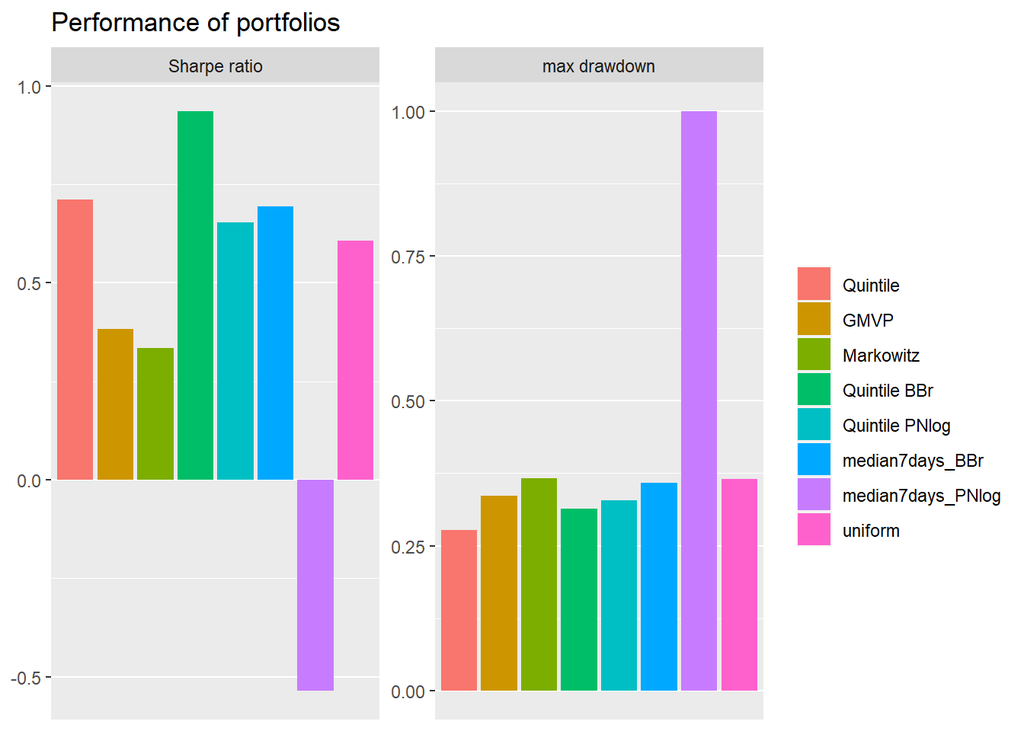

```r
summaryBarPlot(bt_sum, measures = c("Sharpe ratio", "max drawdown"))
```

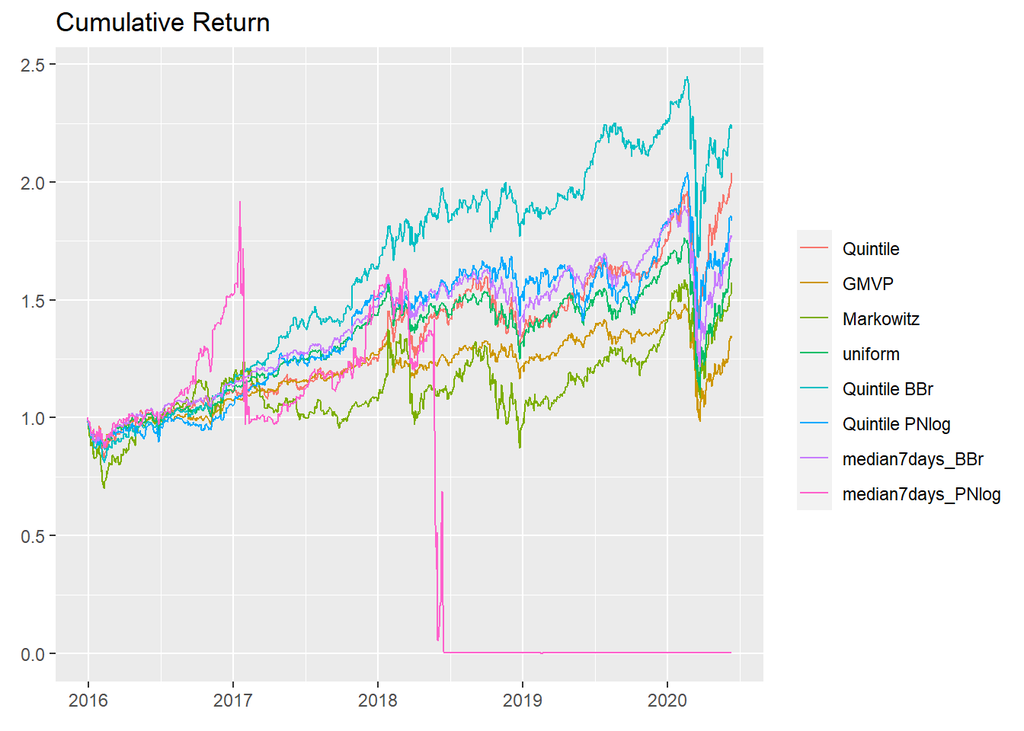

```r
#backtestBoxPlot(bt, measure = "Sharpe ratio")

backtestChartCumReturns(bt, c("Quintile", "GMVP","Markowitz","uniform","Quintile BBr","Quintile PNlog","median7days_BBr","median7days_PNlog"))
```

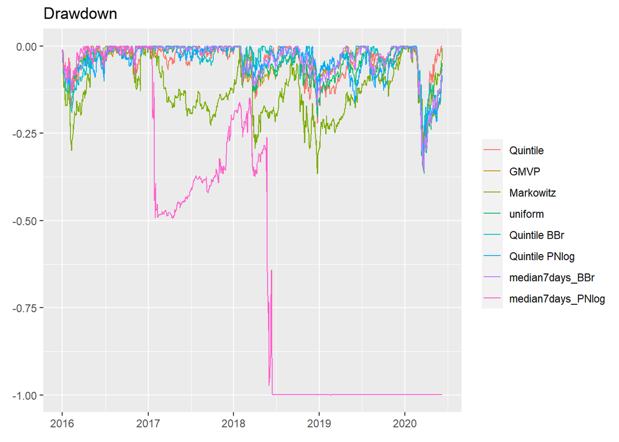

```r
backtestChartDrawdown(bt, c("Quintile", "GMVP","Markowitz","uniform","Quintile BBr","Quintile PNlog","median7days_BBr","median7days_PNlog"))
```

```r
library(ggfortify)
# backtest without transaction costs
bt <- portfolioBacktest(quintile_BBr, data)
```

```
##
##  [Backtesting 1 portfolios over 1 datasets (periodicity = daily data)]
```

```r
# backtest with costs of 15 bps
bt_tc <- portfolioBacktest(quintile_BBr, data,
                           cost = list(buy = 15e-4, sell = 15e-4))
```

```
##
##  [Backtesting 1 portfolios over 1 datasets (periodicity = daily data)]
```

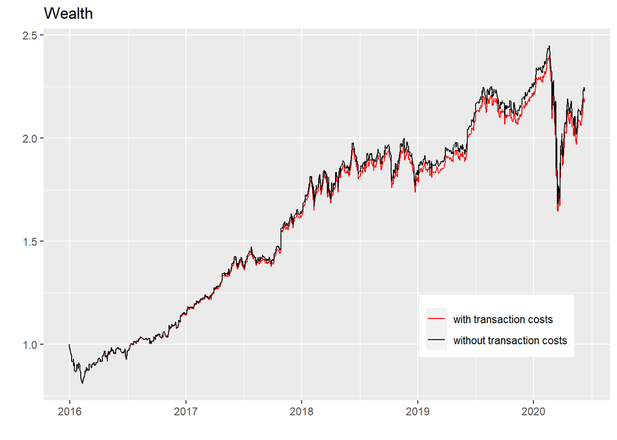

```r
# plot wealth time series

wealth<- cbind(bt$fun1$dataset$wealth,bt_tc$fun1$dataset$wealth)
colnames(wealth) <- c("without transaction costs", "with transaction costs")

autoplot(wealth, facets = FALSE, main = "Wealth") +
  theme(legend.title = element_blank()) +
  theme(legend.position = c(0.8, 0.2)) +
  scale_color_manual(values = c("red", "black"))
```

```r
bt <- portfolioBacktest(portfolios, data, benchmark = c("uniform"))
```

```
##
##  [Backtesting 7 portfolios over 1 datasets (periodicity = daily data)]
##
##  [Backtesting 1 portfolios over 1 datasets (periodicity = daily data)]
```

```r
names(bt)
```

```
## [1] "Quintile"          "GMVP"              "Markowitz"
## [4] "Quintile BBr"      "Quintile PNlog"    "median7days_BBr"
## [7] "median7days_PNlog" "uniform"
```

```r
# define a portfolio with parameters "lookback", "quintile", and "average_type"

quintilelookback_BBr <- function(dataset) {
  X <- tail(dataset$BBr,lookback)
  X[is.na(X)]<-0
  mu <- switch(average_type,
               "mean" = colMeans(X),
               "median" = apply(X, MARGIN = 2, FUN = median))
  idx <- sort(mu, decreasing = TRUE, index.return = TRUE)$ix
  w <- rep(0, ncol(X))
  w[idx[1:ceiling(quintile*ncol(X))]] <- 1/ceiling(quintile*ncol(X))
  return(w)
}

# then automatically generate multiple versions with randomly chosen parameters
portfolio_list <- genRandomFuns(portfolio_fun = quintilelookback_BBr,
                                params_grid = list(lookback = c(3, 5, 7, 14),
                                                   quintile = 1:5 / 10,
                                                   average_type = c("mean", "median")),
                                name = "Quintile",
                                N_funs = 40)# Generating 40 functions out of a total of 40 possible combinations.
```

```
## Generating 40 functions out of a total of 40 possible combinations.
```

```r
bt <- portfolioBacktest(portfolio_list, data)
```

```
##
##  [Backtesting 40 portfolios over 1 datasets (periodicity = daily data)]
```

```
## Parameter grid:
```

```
##    lookback = c(3, 5, 7, 14)
##    quintile = c(0.1, 0.2, 0.3, 0.4, 0.5)
##    average_type = c("mean", "median")
```

```
##
## Parameter types: 0 fixed, 2 variable numeric, and 1 variable non-numeric.
```

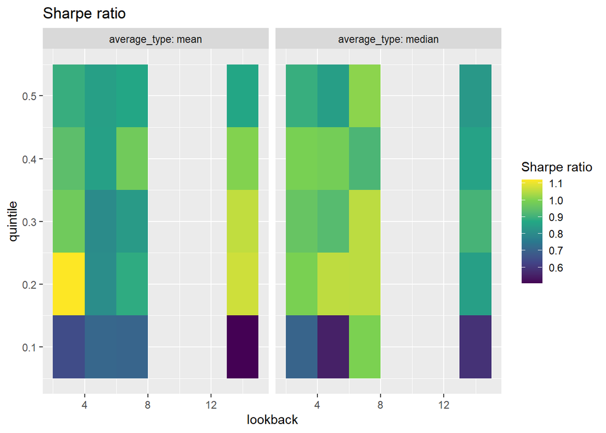

```r
plotPerformanceVsParams(bt)
```

```r
bt <- portfolioBacktest(portfolios, data, show_progress_bar = TRUE)
```

```
##
##  [Backtesting 7 portfolios over 1 datasets (periodicity = daily data)]
```

```
##
##  Backtesting function Quintile        (1/7)
```

```
##
##  Backtesting function GMVP            (2/7)
```

```
##
##  Backtesting function Markowitz       (3/7)
```

```
##
##  Backtesting function Quintile BBr    (4/7)
```

```
##
##  Backtesting function Quintile PNlog  (5/7)
```

```
##
##  Backtesting function median7days_BBr (6/7)
```

```
##
##  Backtesting function median7days_PNlog (7/7)
```

```r
portfun <- Markowitz_portfolio_fun
```